# Google Data Analytics Capstone Project

Mohamed Lashin

2022-12-19

## Introduction

Welcome to Cyclistic bike-share analysis case study which is the capstone project for the Google Data Analytics certificate. Cyclistic is a fictional bike-share company that would use this analysis for a new marketing strategy.

## Scenario

The director of marketing believes the company’s future success depends on maximizing the number of annual memberships. Therefore, our team wants to understand how casual riders and annual members use Cyclistic bikes differently. From these insights, our team will design a new marketing strategy to convert casual riders into annual members. But first, Cyclistic executives must approve our recommendations.

## Stakeholders

**Cyclistic** A bike-share program that features more than 5,800 bicycles and 600 docking stations.  
**Lily Moreno** The director of marketing and your manager.  
**Cyclistic marketing analytics team** A team of data analysts who are responsible for collecting, analyzing, and reporting data that helps guide Cyclistic marketing strategy.  
**Cyclistic executive team** The notoriously detail-oriented executive team will decide whether to approve the recommended marketing program.

## The Business Task

The marketing team task is to make a future marketing strategy that would help converting casual riders to annual members, so we will analyse past data to find trends that would help us understanding how annual members and casual riders use Cyclistic bikes differently.

## Data Source

We will use Cyclistic’s historical trip data for 12 months from 10-2021 to 09-2022 to analyze and identify trends. For the purposes of this case study, the datasets are appropriate and will enable you to answer the business questions. The data has been made available by Motivate International Inc. under this [license](https://ride.divvybikes.com/data-license-agreement).)

## Setting up the environment

We will use R programming language as our main analysis tool for this project, now we will start including the packages we will use.

```r
library(tidyverse)
library(lubridate)
```

## Preparing The Data

After downloading the 12 months data from the data source as .CSV files we will load the data to data frames the combine them for easier analysis.

```r
oct2021 <- read_csv("original_trip_data_CSV/202110-divvy-tripdata.csv")
nov2021 <- read_csv("original_trip_data_CSV/202111-divvy-tripdata.csv")
dec2021 <- read_csv("original_trip_data_CSV/202112-divvy-tripdata.csv")
jan2022 <- read_csv("original_trip_data_CSV/202201-divvy-tripdata.csv")
feb2022 <- read_csv("original_trip_data_CSV/202202-divvy-tripdata.csv")
mar2022 <- read_csv("original_trip_data_CSV/202203-divvy-tripdata.csv")
apr2022 <- read_csv("original_trip_data_CSV/202204-divvy-tripdata.csv")
may2022 <- read_csv("original_trip_data_CSV/202205-divvy-tripdata.csv")
jun2022 <- read_csv("original_trip_data_CSV/202206-divvy-tripdata.csv")
jul2022 <- read_csv("original_trip_data_CSV/202207-divvy-tripdata.csv")
aug2022 <- read_csv("original_trip_data_CSV/202208-divvy-tripdata.csv")
sep2022 <- read_csv("original_trip_data_CSV/202209-divvy-tripdata.csv")
```

```r
trip_data <- rbind(oct2021, nov2021, dec2021, jan2022, feb2022, mar2022, apr2022, may2022, jun2022,
                   jul2022, aug2022, sep2022)
```

We will make a backup copy of our data

```r
trip_data1 <- trip_data
```

Checking the structure of the data

```r
str(trip_data1)
```

```
## spec_tbl_df [5,828,235 × 13] (S3: spec_tbl_df/tbl_df/tbl/data.frame)
##  $ ride_id           : chr [1:5828235] "620BC6107255BF4C" "4471C70731AB2E45" "26CA69D43D15EE14" "362947F0437E1514" ...
##  $ rideable_type     : chr [1:5828235] "electric_bike" "electric_bike" "electric_bike" "electric_bike" ...
##  $ started_at        : POSIXct[1:5828235], format: "2021-10-22 12:46:42" "2021-10-21 09:12:37" ...
##  $ ended_at          : POSIXct[1:5828235], format: "2021-10-22 12:49:50" "2021-10-21 09:14:14" ...
##  $ start_station_name: chr [1:5828235] "Kingsbury St & Kinzie St" NA NA NA ...
##  $ start_station_id  : chr [1:5828235] "KA1503000043" NA NA NA ...
##  $ end_station_name  : chr [1:5828235] NA NA NA NA ...
##  $ end_station_id    : chr [1:5828235] NA NA NA NA ...
##  $ start_lat         : num [1:5828235] 41.9 41.9 41.9 41.9 41.9 ...
##  $ start_lng         : num [1:5828235] -87.6 -87.7 -87.7 -87.7 -87.7 ...
##  $ end_lat           : num [1:5828235] 41.9 41.9 41.9 41.9 41.9 ...
##  $ end_lng           : num [1:5828235] -87.6 -87.7 -87.7 -87.7 -87.7 ...
##  $ member_casual     : chr [1:5828235] "member" "member" "member" "member" ...
##  - attr(*, "spec")=
##   .. cols(
##   ..   ride_id = col_character(),
##   ..   rideable_type = col_character(),
##   ..   started_at = col_datetime(format = ""),
##   ..   ended_at = col_datetime(format = ""),
##   ..   start_station_name = col_character(),
##   ..   start_station_id = col_character(),
##   ..   end_station_name = col_character(),
##   ..   end_station_id = col_character(),
##   ..   start_lat = col_double(),
##   ..   start_lng = col_double(),
##   ..   end_lat = col_double(),
##   ..   end_lng = col_double(),
##   ..   member_casual = col_character()
##   .. )
##  - attr(*, "problems")=<externalptr>
```

```r
dim(trip_data1)  #checking dimensions of the data
```

```
## [1] 5828235      13
```

```r
colnames(trip_data1)  #View columns names
```

```
##  [1] "ride_id"            "rideable_type"      "started_at"
##  [4] "ended_at"           "start_station_name" "start_station_id"
##  [7] "end_station_name"   "end_station_id"     "start_lat"
## [10] "start_lng"          "end_lat"            "end_lng"
## [13] "member_casual"
```

## Processing The Data

we will start processing the data by renaming some columns for more clarification.

```r
trip_data1 <- rename(trip_data1, trip_id = ride_id, bike_type = rideable_type,
                     customer_type = member_casual)
```

Then we will add some columns that would help us in analyzing data

```r
trip_data1 <- mutate(trip_data1, trip_length = ended_at - started_at)
trip_data1$trip_length <- as.double((trip_data1$trip_length)/60)   #trip length converted to minutes

trip_data1 <- mutate(trip_data1, date = as_date(started_at))
trip_data1 <- mutate(trip_data1, month = month(started_at, label = T))
trip_data1 <- mutate(trip_data1, hour = hour(started_at))
trip_data1 <- mutate(trip_data1, day_of_week = wday(started_at, label = T))
```

We will make exploratory analysis and check the statistics of our variables

```r
summary(trip_data1)   #Viewing some statistics summary for our data
```

```
##    trip_id           bike_type           started_at
##  Length:5828235     Length:5828235     Min.   :2021-10-01 00:00:09.00
##  Class :character   Class :character   1st Qu.:2022-02-28 19:21:08.50
##  Mode  :character   Mode  :character   Median :2022-06-08 06:41:28.00
##                                        Mean   :2022-05-06 21:39:18.18
##                                        3rd Qu.:2022-08-02 11:26:01.00
##                                        Max.   :2022-09-30 23:59:56.00
##
##     ended_at                     start_station_name start_station_id
##  Min.   :2021-10-01 00:03:11.0   Length:5828235     Length:5828235
##  1st Qu.:2022-02-28 19:34:02.5   Class :character   Class :character
##  Median :2022-06-08 06:55:07.0   Mode  :character   Mode  :character
##  Mean   :2022-05-06 21:58:54.2
##  3rd Qu.:2022-08-02 11:46:26.0
##  Max.   :2022-10-05 19:53:11.0
##
##  end_station_name   end_station_id       start_lat       start_lng
##  Length:5828235     Length:5828235     Min.   :41.64   Min.   :-87.84
##  Class :character   Class :character   1st Qu.:41.88   1st Qu.:-87.66
##  Mode  :character   Mode  :character   Median :41.90   Median :-87.64
##                                        Mean   :41.90   Mean   :-87.65
##                                        3rd Qu.:41.93   3rd Qu.:-87.63
##                                        Max.   :45.64   Max.   :-73.80
##
##     end_lat         end_lng       customer_type       trip_length
##  Min.   :41.39   Min.   :-88.97   Length:5828235     Min.   :-10353.35
##  1st Qu.:41.88   1st Qu.:-87.66   Class :character   1st Qu.:     5.93
##  Median :41.90   Median :-87.64   Mode  :character   Median :    10.48
##  Mean   :41.90   Mean   :-87.65                      Mean   :    19.60
##  3rd Qu.:41.93   3rd Qu.:-87.63                      3rd Qu.:    18.85
##  Max.   :42.37   Max.   :-87.30                      Max.   : 40705.02
##  NA's   :5844    NA's   :5844
##       date                month              hour       day_of_week
##  Min.   :2021-10-01   Jul    : 823488   Min.   : 0.00   Sun:798664
##  1st Qu.:2022-02-28   Aug    : 785932   1st Qu.:11.00   Mon:752849
##  Median :2022-06-08   Jun    : 769204   Median :15.00   Tue:817314
##  Mean   :2022-05-06   Sep    : 701339   Mean   :14.22   Wed:820150
##  3rd Qu.:2022-08-02   May    : 634858   3rd Qu.:18.00   Thu:837246
##  Max.   :2022-09-30   Oct    : 631226   Max.   :23.00   Fri:843977
##                       (Other):1482188                   Sat:958035
```

```r
trip_data1 <- trip_data1[!trip_data1$trip_length < 1, ]
```

Removing any columns we will not use

```r
trip_data1 <- trip_data1 %>% select(trip_id, bike_type, started_at, ended_at,date, month,
                                    hour,trip_length,day_of_week, start_station_name,
                                    start_station_id,end_station_name, end_station_id,customer_type)
```

Remove any missing data

```r
trip_data1 <- drop_na(trip_data1)
```

Remove duplicated records if found

```r
trip_data1 <- distinct(trip_data1)
```

## Analyzing and Visualizing Data

Now we have a clean copy of our data and we will make some aggregations and calculations to get some trends from it. Getting the average and maximum trip length

```r
trip_data1 %>%
  summarise(average_trip_length = mean(trip_length),
            maximum_trip_length = max(trip_length))
```

```
## # A tibble: 1 × 2
##   average_trip_length maximum_trip_length
##                 <dbl>               <dbl>
## 1                17.8              40705.
```

Getting the total number of trips made by each customer type

```r
#get the total number of every customer type
trip_data1 %>%
  group_by(customer_type) %>%
  summarise(total = n())
```

```
## # A tibble: 2 × 2
##   customer_type   total
##   <chr>           <int>
## 1 casual        1780290
## 2 member        2620007
```

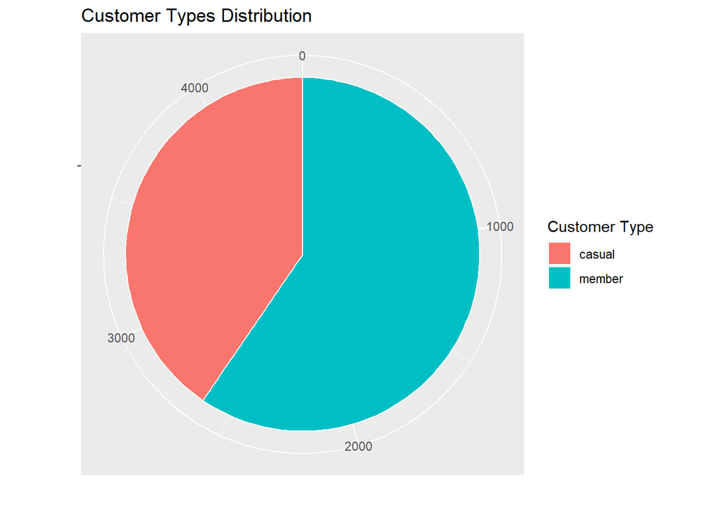

```r
trip_data1 %>%
  group_by(customer_type) %>%
  summarise(total = n()) %>%
  ggplot()+
  geom_col(aes(x= "", y = total/1000, fill = customer_type), color = "white", width = 1, stat = "identity")+
  labs(x = "", y = "", title = "Customer Types Distribution", fill = "Customer Type")+
  coord_polar(theta = "y")+
  scale_y_continuous()
```

The pie chart above shows that total number of trips made by annual members is larger than that made by casual members.

Now we will get average and maximum trip length for each customer type.

```r
#get trip length statistics for both customer types
trip_data1 %>%
  group_by(customer_type) %>%
  summarise(mean_length = mean(trip_length), max_length = max(trip_length))
```

```
## # A tibble: 2 × 3
##   customer_type mean_length max_length
##   <chr>               <dbl>      <dbl>
## 1 casual               25.3     40705.
## 2 member               12.7      1493.
```

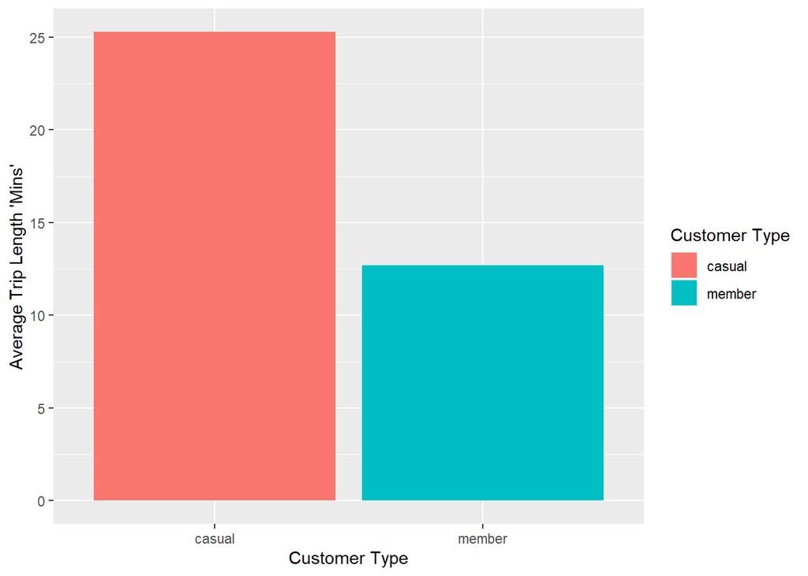

```r
trip_data1 %>%
  group_by(customer_type) %>%
  summarise(avg_trip_length = mean(trip_length)) %>%
  ggplot()+
  geom_col(aes(x = customer_type, y = avg_trip_length, fill = customer_type))+
  labs(x = "Customer Type", y = "Average Trip Length 'Mins'", fill = "Customer Type")
```

The Above bar chart shows that casual members records longer trips in average.

```r
#calculate the mode day of week
trip_data1 %>%
  group_by(day_of_week) %>%
  count()
```

```
## # A tibble: 7 × 2
## # Groups:   day_of_week [7]
##   day_of_week      n
##   <ord>        <int>
## 1 Sun         606067
## 2 Mon         573824
## 3 Tue         621107
## 4 Wed         619201
## 5 Thu         626748
## 6 Fri         626525
## 7 Sat         726825
```

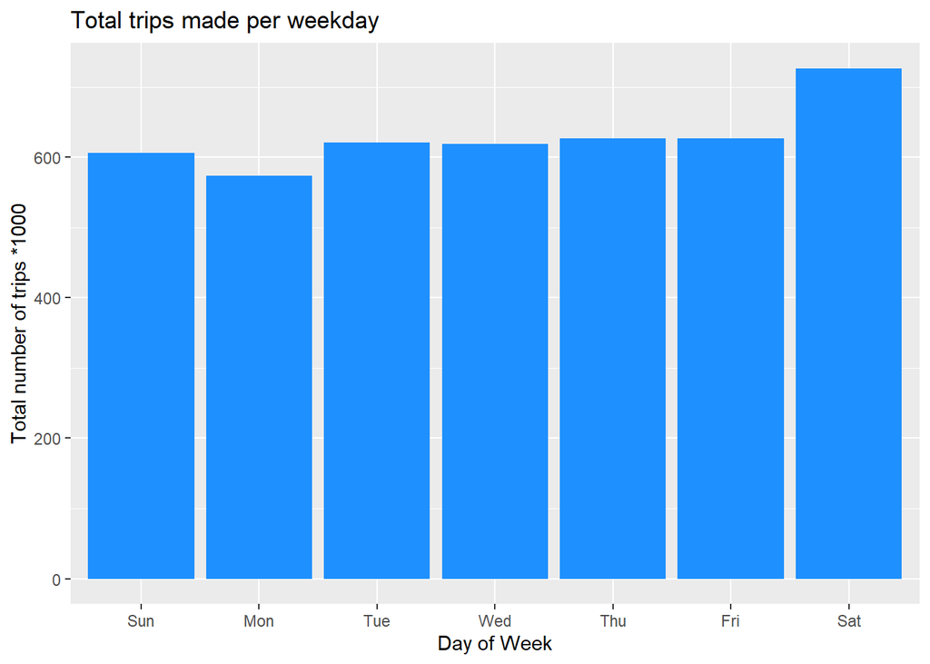

```r
trip_data1 %>%
  group_by(day_of_week) %>%
  summarise(total_trips = n()) %>%
  ggplot()+
  geom_col(aes(x = day_of_week, y = total_trips/1000), fill = "dodgerblue")+
  labs(title = "Total trips made per weekday", x = "Day of Week", y = "Total number of trips *1000")
```

As we see Saturday is the mode day of week per total number of trips, the rest week days records close numbers.

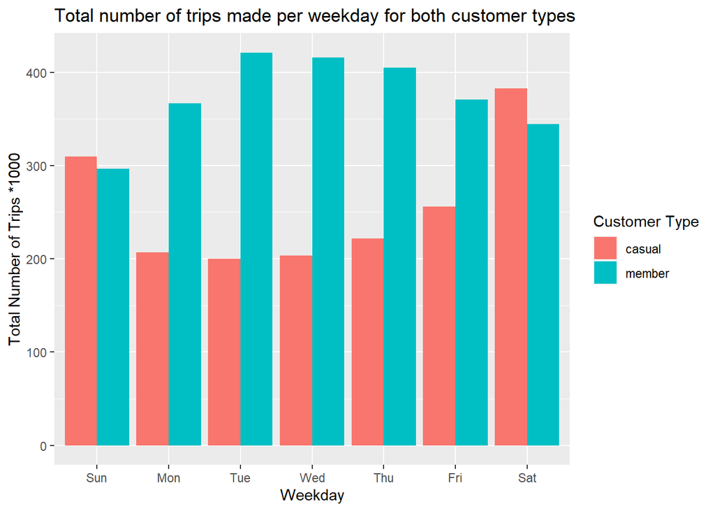

```r
trip_data1 %>%
  group_by(customer_type, day_of_week) %>%
  summarise(total_trips = n()) %>%
  arrange(customer_type, day_of_week) %>%
  ggplot()+
  geom_col(aes(x = day_of_week, y = total_trips/1000, fill = customer_type), position = "dodge")+
  labs(title = "Total number of trips made per weekday for both customer types", x = "Weekday",
         y = "Total Number of Trips *1000", fill = "Customer Type")
```

As above chart shows, casual members have more trips than annual members only during weekend days while annual members have more trips during weekdays.

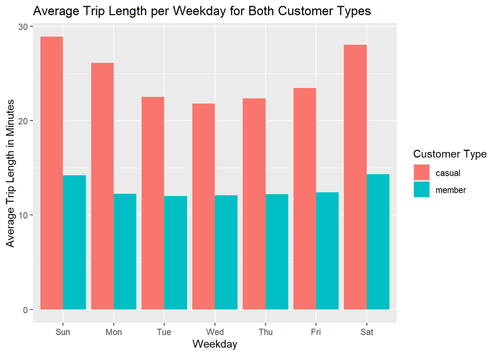

```r
trip_data1 %>%
  group_by(customer_type, day_of_week) %>%
  summarise(average_trip_length = mean(trip_length)) %>%
  arrange(customer_type, day_of_week) %>%
  ggplot()+
  geom_col(aes(x = day_of_week, y = average_trip_length, fill = customer_type), position = "dodge")+
  labs(title = "Average Trip Length per Weekday for Both Customer Types", x = "Weekday",
         y = "Average Trip Length in Minutes", fill = "Customer Type")
```

As we see casual riders average much longer trips than annual members during all the days of week.

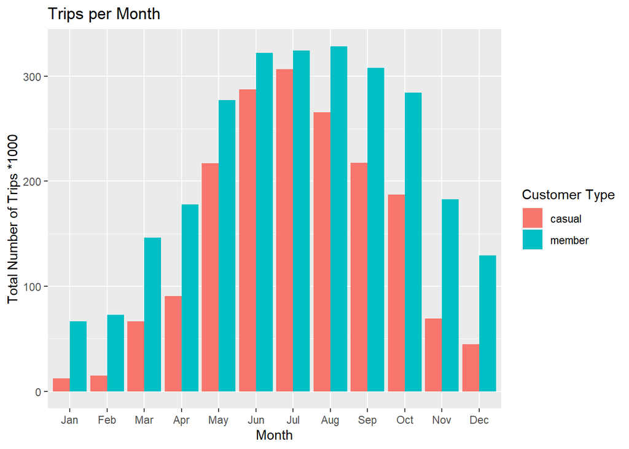

```r
trip_data1 %>%
  group_by(month, customer_type) %>%
  summarise(total = n()) %>%
  ggplot()+
  geom_col(aes(x = month, y = total/1000, fill = customer_type), position = "dodge")+
  labs(title = "Trips per Month", x = "Month", y= "Total Number of Trips *1000",
       fill = "Customer Type")
```

The total number of trips reaches its peak in the middle months of the year, annual members records more trips numbers than casual riders in all year months.

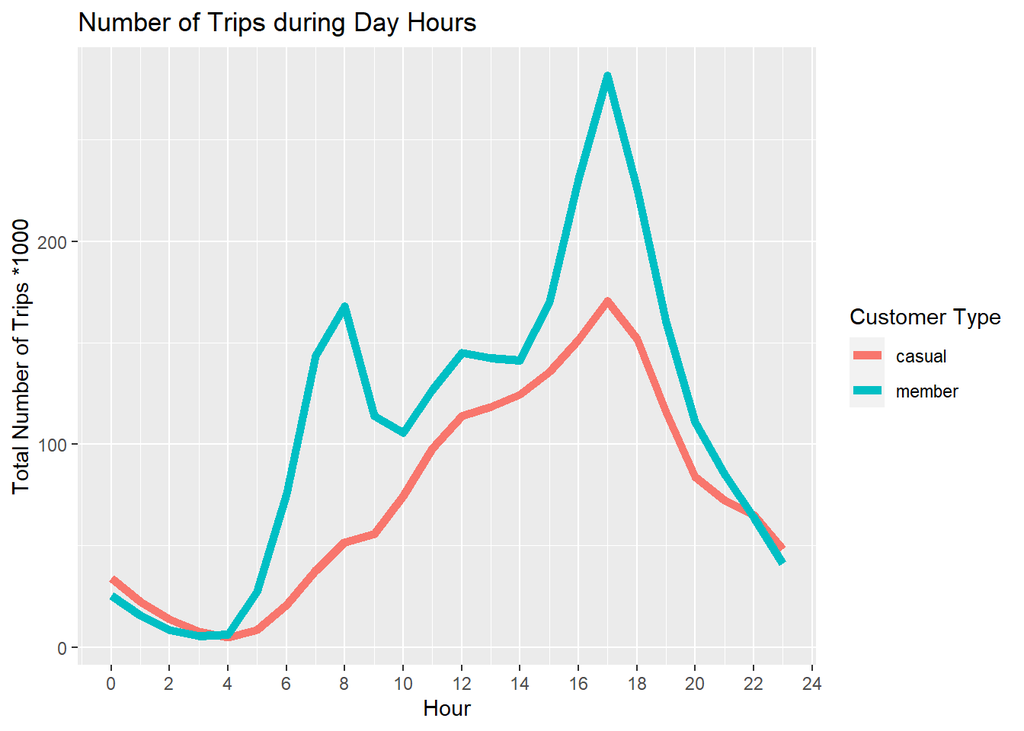

```r
trip_data1 %>%
  group_by(hour, customer_type) %>%
  summarise(total = n()) %>%
  ggplot()+
  geom_line(aes(x = hour, y = total/1000, color = customer_type), size = 2)+
  labs(title = "Number of Trips during Day Hours", x = "Hour", y= "Total Number of Trips *1000",
       color = "Customer Type")+
  scale_x_continuous(n.breaks = 13)
```

```r
trip_data1 %>%
  group_by(bike_type) %>%
  summarise(total_number = n())
```

```
## # A tibble: 3 × 2
##   bike_type     total_number
##   <chr>                <int>
## 1 classic_bike       2696174
## 2 docked_bike         188387
## 3 electric_bike      1515736
```

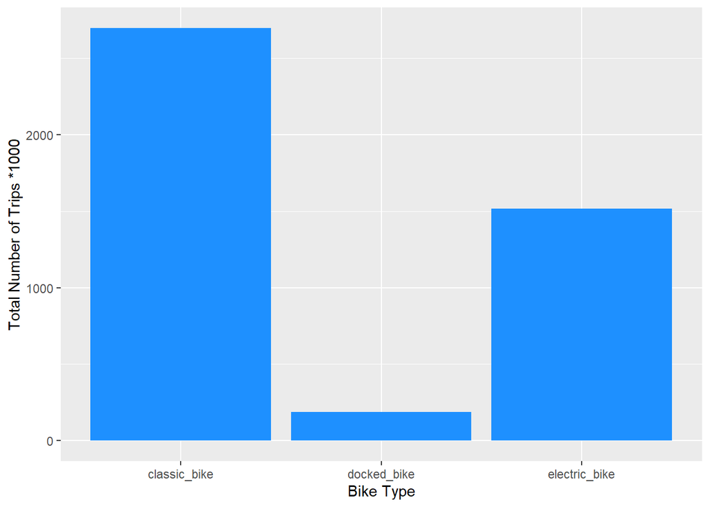

```r
trip_data1 %>%
  group_by(bike_type) %>%
  summarise(total_number = n()) %>%
  ggplot()+
  geom_col(aes(x= bike_type, y = total_number/1000), fill = "dodgerblue")+
  labs(x= "Bike Type", y = "Total Number of Trips *1000")
```

Classic type is the most demanded bike type by far, electric bike comes as second demanded bike, and docked bike as the least one.

```r
#calculate the total number of every bike type used by each customer type
trip_data1 %>%
  group_by(bike_type, customer_type) %>%
  summarise(trips_number = n())
```

```
## # A tibble: 5 × 3
## # Groups:   bike_type [3]
##   bike_type     customer_type trips_number
##   <chr>         <chr>                <int>
## 1 classic_bike  casual              925753
## 2 classic_bike  member             1770421
## 3 docked_bike   casual              188387
## 4 electric_bike casual              666150
## 5 electric_bike member              849586
```

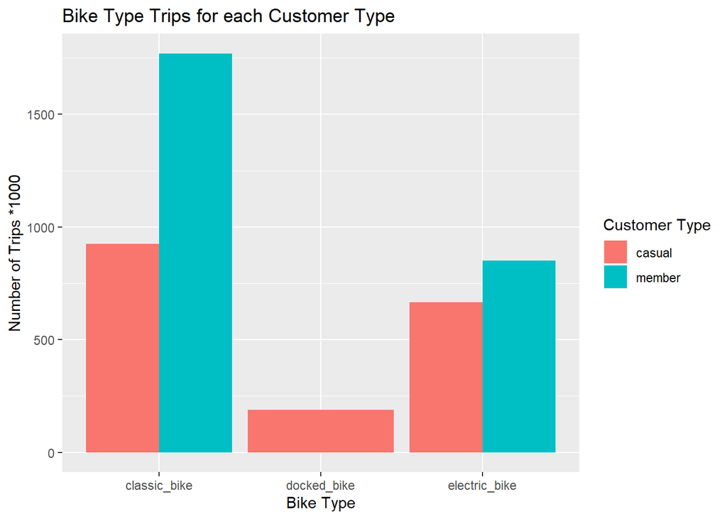

```r
trip_data1 %>%
  group_by(bike_type, customer_type) %>%
  summarise(trips_number = n()) %>%
  ggplot()+
  geom_col(aes(x = bike_type, y = trips_number/1000, fill = customer_type), position = "dodge")+
  labs(x= "Bike Type", y='Number of Trips *1000', title='Bike Type Trips for each Customer Type',
       fill = "Customer Type")
```

- Classic bikes are demanded by annual members more than casual riders approximately twice the number.
- During the period analyzed, docked bikes are only demanded by casual riders.
- Electric bikes are demanded by annual members slightly more than casual riders.

## Recommendations

- Since the number of trips made by casual riders increases in the summer months we can put more marketing resources towards these months to attract more members.
- Casual riders records longer trips so we can discuss some discounts on the long trips to attract the to buy annual membership.
- Docked bikes are the least demanded so we should discuss a discount to attract more requests on it.
- Peak hours show that riders have made more trips at hours before and after work so we should target riders who uses bikes to commute for their work.